# Analyzing key indicators of Heart Disease

by Mugilan

2023-07-04

Let us first load libraries and then the data set.

```r
# Loading Libraries
library(tidyverse)
```

```r
library(lubridate)
library(dplyr)
library(ggplot2)
library(tidyr)
library(readr)

# Loading data
d <- read.csv('./heart_2020.csv')
```

Let us have a glance at it:

```r
head(d)
```

```
##   HeartDisease   BMI Smoking AlcoholDrinking Stroke PhysicalHealth MentalHealth
## 1           No 16.60     Yes              No     No              3           30
## 2           No 20.34      No              No    Yes              0            0
## 3           No 26.58     Yes              No     No             20           30
## 4           No 24.21      No              No     No              0            0
## 5           No 23.71      No              No     No             28            0
## 6          Yes 28.87     Yes              No     No              6            0
##   DiffWalking    Sex AgeCategory  Race Diabetic PhysicalActivity GenHealth
## 1          No Female       55-59 White      Yes              Yes Very good
## 2          No Female 80 or older White       No              Yes Very good
## 3          No   Male       65-69 White      Yes              Yes      Fair
## 4          No Female       75-79 White       No               No      Good
## 5         Yes Female       40-44 White       No              Yes Very good
## 6         Yes Female       75-79 Black       No               No      Fair
##   SleepTime Asthma KidneyDisease SkinCancer
## 1         5    Yes            No        Yes
## 2         7     No            No         No
## 3         8    Yes            No         No
## 4         6     No            No        Yes
## 5         8     No            No         No
## 6        12     No            No         No
```

We shall proceed to find correlations within this data set, to find possible indicators of heart disease.

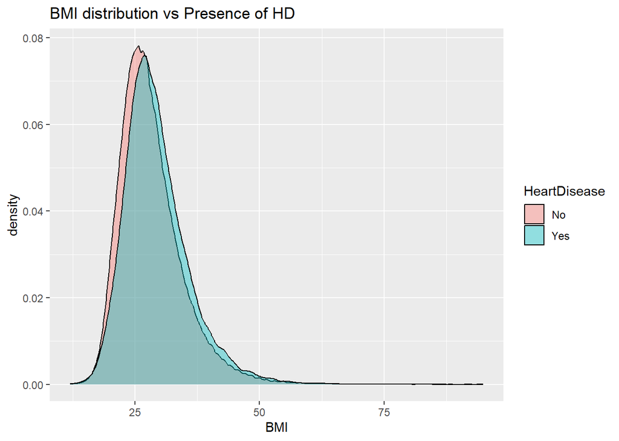

```r
ggplot(d,
       aes(x = BMI,
           fill = HeartDisease)) +
  geom_density(alpha = 0.4) +
  labs(title = "BMI distribution vs Presence of HD")
```

As you can notice, patients with HD have a slightly higher BMI than patients without. Here is another plot:

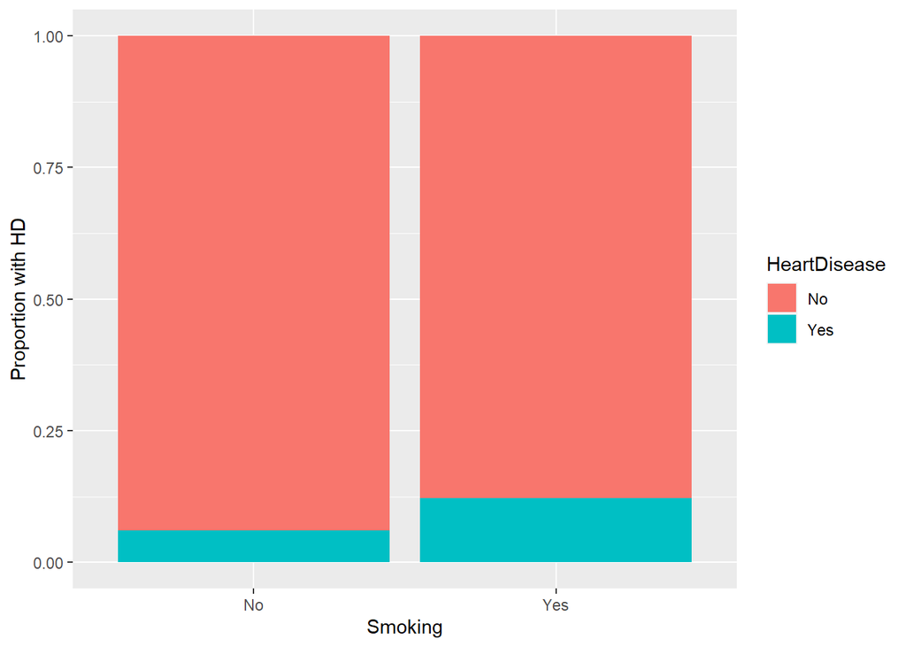

```r
ggplot(d,
       aes(x = Smoking,
           fill = HeartDisease)) +
  geom_bar(position = "fill") +
  labs(y = "Proportion with HD")
```

It is clearly visible that smoking increases the chance of HD significantly.

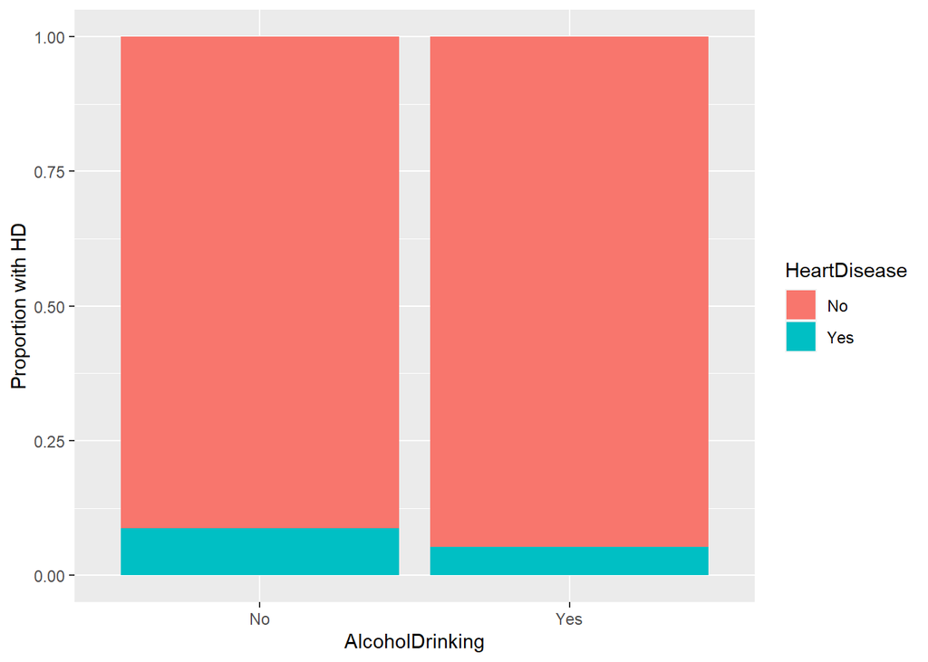

```r
ggplot(d,
       aes(x = AlcoholDrinking,
           fill = HeartDisease)) +
  geom_bar(position = "fill") +
  labs(y = "Proportion with HD")
```

It may be a sampling bias, but according to this data, alcohol consumers have a reduced chance of HD. It also may not be a relevant factor. We shall now investigate the age distribution of HD.

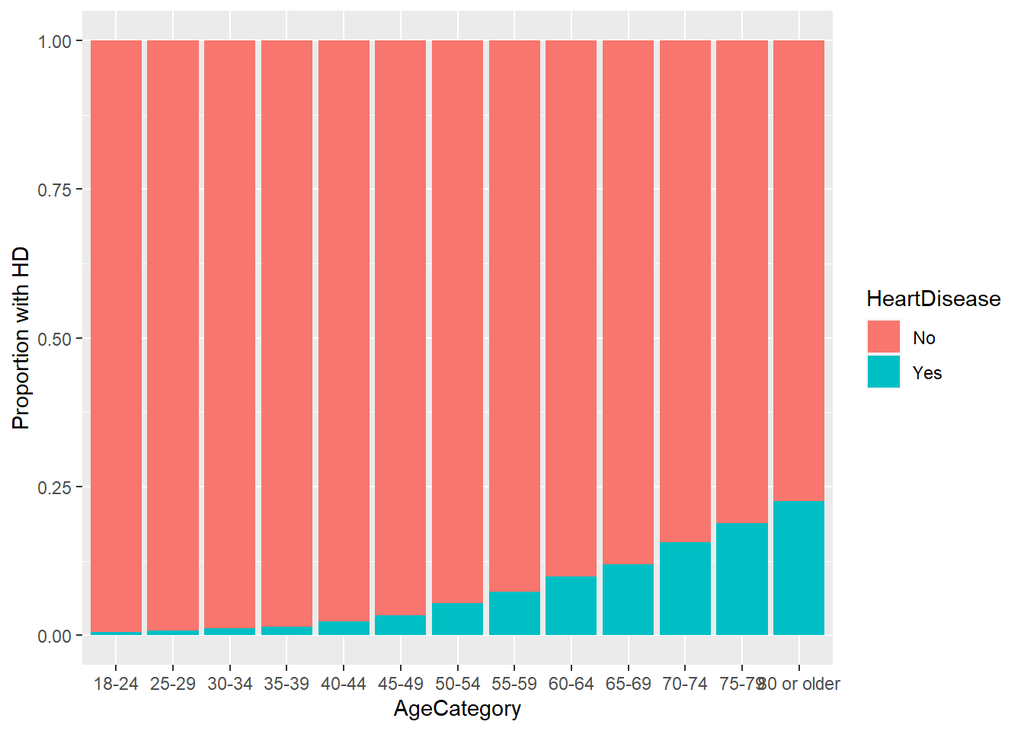

```r
ggplot(d,
       aes(x = AgeCategory,
           fill = HeartDisease)) +
  geom_bar(position = "fill") +
  labs(y = "Proportion with HD")
```

It is very evident that proportion of people with HD increases with age. Next, we shall explore the connection between Diabetic & HD.

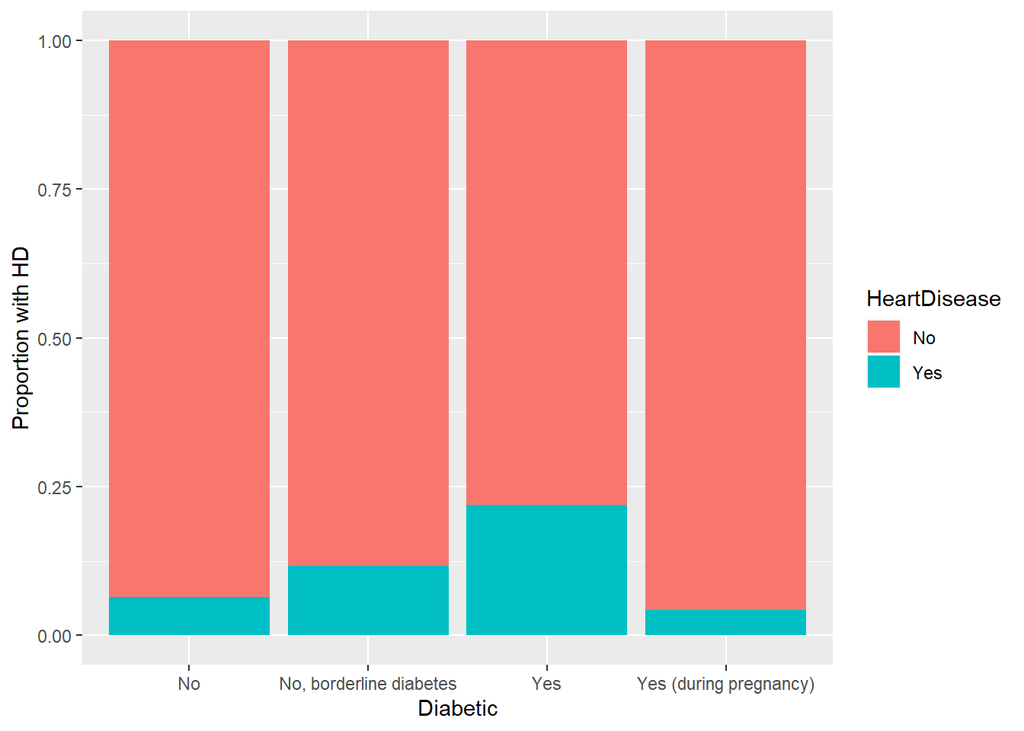

```r
ggplot(d,
       aes(x = Diabetic,
           fill = HeartDisease)) +
  geom_bar(position = "fill") +
  labs(y = "Proportion with HD")
```

As you can observe, presence of Diabetes massively increases the chance of HD. We will now see if Diabetes and absence of Physical Activity are correlated.

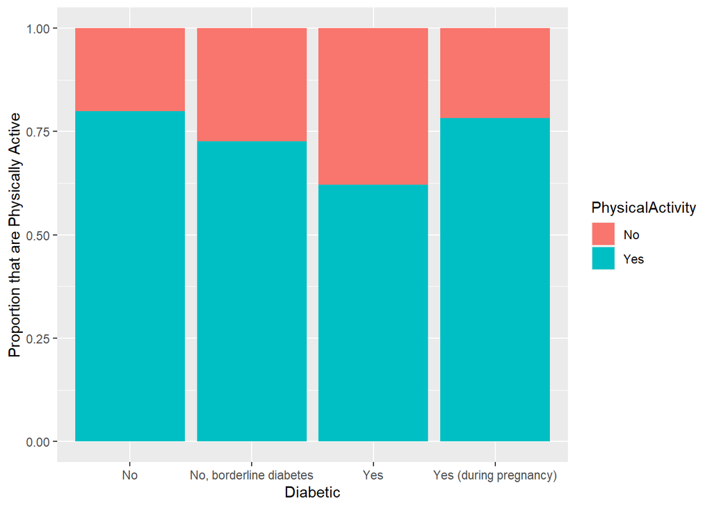

```r
ggplot(d,
       aes(x = Diabetic,
           fill = PhysicalActivity)) +
  geom_bar(position = "fill") +
  labs(y = "Proportion that are Physically Active")
```

There seems to be a correlation. Diabetic and borderline diabetic patients have a lack of Physical Activity. Next up, General health vs HD.

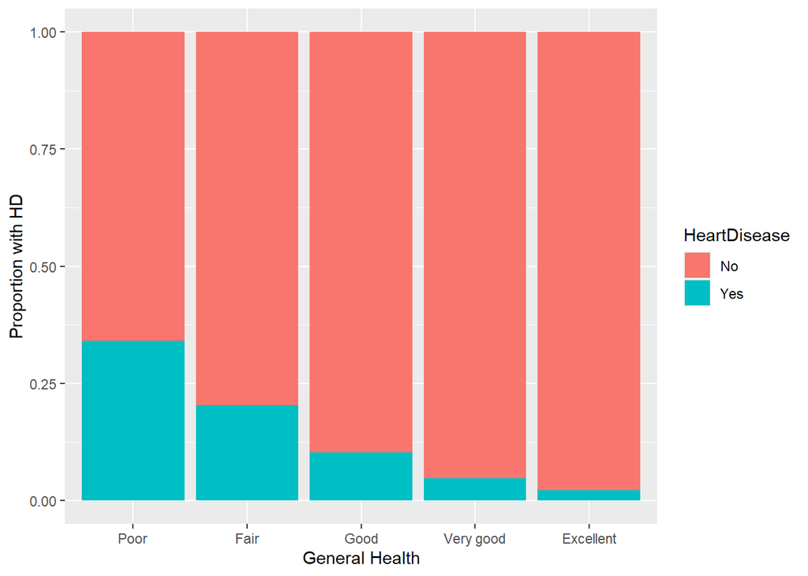

```r
ggplot(d,
       aes(x = reorder(GenHealth, desc(HeartDisease)),
           fill = HeartDisease)) +
  geom_bar(position = "fill") +
  labs(y = "Proportion with HD", x = "General Health")
```

There is a very strong correlation between general health and presence of HD. However, it is not easy to determine the direction of the correlation. Finally, we shall explore if HD is correlated with sleep time.

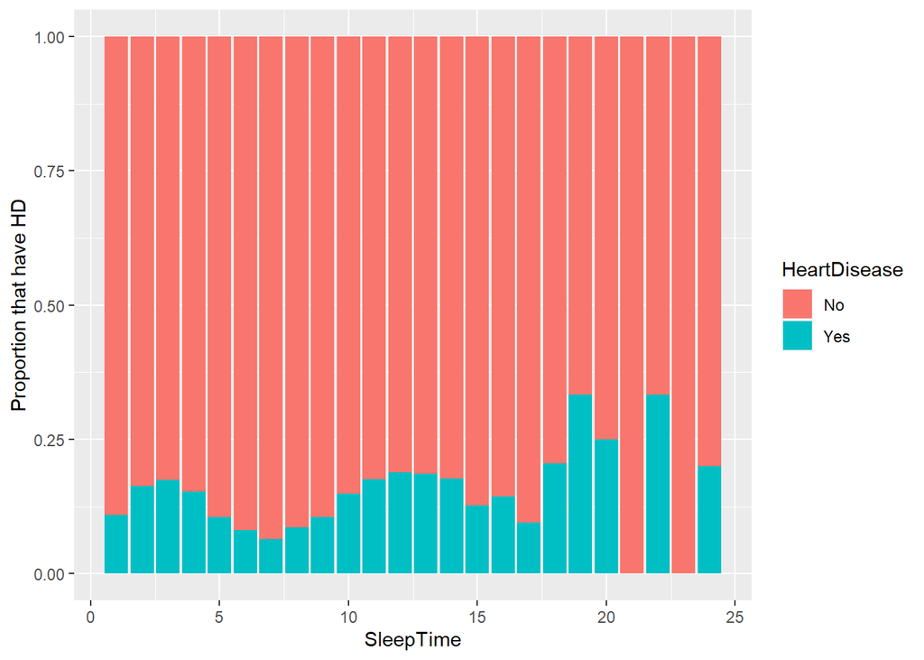

```r
ggplot(d,
       aes(x = SleepTime,
           fill = HeartDisease)) +
  geom_bar(position = "fill") +
  labs(y = "Proportion that have HD")
```

Sleep durations of 6-8 hours correlate with minimum risk of HD.